# SCEG-HiC on paired scATAC-seq/scRNA-seq data of PBMC-CD4T

XuanLiang

Compiled: May 12, 2026

In this vignette, we demonstrate the capability of SCEG-HiC to infer enhancer–gene links by applying it to paired scATAC-seq/RNA-seq data. Specifically, we use a publicly available 10x Genomics Multiome dataset from human PBMCs and select only CD4+ T cells for processing using the single-cell retention approach.

To begin, we require a Seurat object containing paired scATAC-seq/scRNA-seq data. For this demonstration, we utilize publicly available multi-omics dataset from human PBMCs, processed as described in the [SCEG-HiC on paired scATAC-seq/RNA-seq data of PBMC (aggregation)](https://wuwei77lx.github.io/SCEGHiC/articles/PBMC_multiomic_aggregation.html) The Seurat object file, `PBMC_multiomic.rds` file is also available at [10.5281/zenodo.14849886](https://zenodo.org/record/14849886).

**Note**: Due to the stochastic nature of `SCTransform`, particularly in generating `scale.data`, the UMAP embedding produced by re-running the code may differ slightly from that in the provided `PBMC_multiomic.rds` file.

The implementation of SCEG-HiC is seamlessly compatible with the standard workflow of the Seurat/Signac packages. The SCEG-HiC pipeline consists of the following two main steps:

- **Infer enhancer–gene links**: Apply the SCEG-HiC model to the processed Seurat object, incorporating human bulk average Hi-C data as a chromatin conformation prior to enhance the inference of enhancer–gene links.
- **Visualize enhancer–gene links**: Generate graphical outputs such as arc diagrams and coverage plots to visualize predicted enhancer–gene links.

## Load the required libraries

```r
library(SCEGHiC)
library(Signac)
library(Seurat)
library(EnsDb.Hsapiens.v86)
library(BSgenome.Hsapiens.UCSC.hg38)
library(ggplot2)
```

## Infer enhancer–gene links

### Preprocess data

Here, we use the single-cell retention approach to handle paired scATAC-seq/RNA-seq data. The scATAC-seq counts are normalized using TF-IDF. We specifically select CD4+ T cells with paired scATAC-seq/RNA-seq data.

```r
# Load processed multi-omics PBMC data
pbmc <- readRDS("PBMC_multiomic.rds")

# Prepare data for SCEG-HiC analysis
# Here, data is processed without aggregation, focusing on the CD4+ T cell type
SCEGdata <- process_data(pbmc, aggregate = FALSE, celltype = "CD4 T", rna_assay = "SCT", atacbinary = FALSE)
```

### Calculate weight

Calculating weights with SCEG-HiC can be time-consuming, especially as the number of selected genes increases. To facilitate this process, SCEG-HiC provides downloadable average Hi-C datasets for both human and mouse (detail [here](https://wuwei77lx.github.io/SCEGHiC/index.html#the-bulk-average-hi-c)). In this case, we select the human average Hi-C data as prior information to calculate enhancer-gene interaction weights.

As an example, we calculate Hi-C weights focusing on the CD4+ T cell marker gene GLB1.

```r
# Alternatively, calculate Hi-C weights for the specific CD4+ T cell marker gene GLB1
weight <- calculateHiCWeights(SCEGdata, species = "Homo sapiens", genome = "hg38", focus_gene = "GLB1", averHicPath = "/mnt/netshare2/liangxuan/data/human_contact/AvgHiC")
```

```
## Processing chromosome chr3...
```

```
## Found 1 TSS loci on chr3.
```

```
## Calculating Hi-C weights for gene GLB1...
```

```
## Finished calculating Hi-C weights for all genes.
```

### Run model

SCEG-HiC employs the wglasso method to infer enhancer-gene links by integrating processed single-cell multi-omics data and normalized bulk average Hi-C contact matrices. The bulk Hi-C matrix is normalized using rank score to improve accuracy. In this example, we run the model focusing on CD4+ T cell marker gene GLB1 to identify their putative enhancer links.

```r
# Example: Run the model focused on Basal cell marker GLB1
results_SCEGHiC <- Run_SCEG_HiC(SCEGdata, weight, focus_gene = "GLB1")
```

```
## Total predicted genes: 1
```

```
## Running model for gene: GLB1
```

```
## [1] "The optimal penalty parameter (rho) selected by BIC is: 0.12"
```

## Visualize enhancer–gene links

### Arc plot visualization of enhancer-gene links

Arc plot visualizes the predicted links between enhancers and target genes as arcs connecting genomic regions, highlighting spatial chromatin interactions inferred by SCEG-HiC.

Arc plot visualization of enhancer-gene links for GLB1.

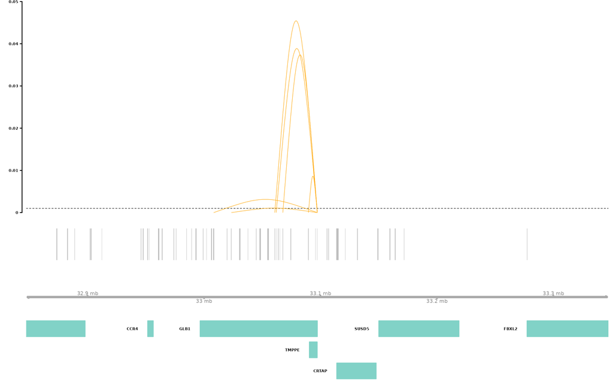

```r
# Download and prepare gene annotation data
# wget https://hgdownload2.soe.ucsc.edu/goldenPath/hg38/bigZips/genes/hg38.refGene.gtf.gz
temp <- "hg38.refGene.gtf.gz"
gene_anno <- rtracklayer::readGFF(temp)

# Rename some columns to match requirements
gene_anno$chromosome <- gene_anno$seqid
gene_anno$gene <- gene_anno$gene_id
gene_anno$transcript <- gene_anno$transcript_id
gene_anno$symbol <- gene_anno$gene_name

# Arc plot visualization of enhancer-gene links for GLB1
connections_Plot(results_SCEGHiC, species = "Homo sapiens", genome = "hg38", focus_gene = "GLB1", cutoff = 0.001, gene_anno = gene_anno)
```